# Data Viz in R: Week 5

A Collection of Non-Random Bits and Final Pieces

Michele Claibourn

2021-11-09

## Project Progress!

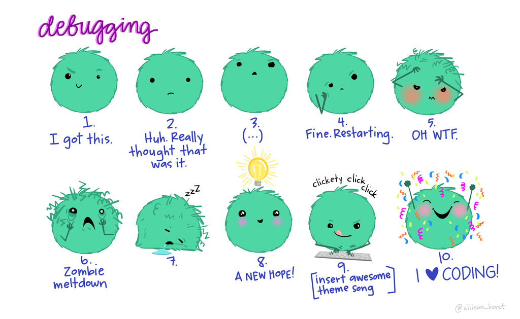

Artwork by @allison_horst

## Advice and Considerations

### From Wilke

Additional choices to make in your visual representations

- Titles, captions, axis labels
- Providing context via legends, annotations, background grids and axis ticks, reference lines, labeling
- Text size (readability, relative to figure)

Telling a story

- A set of observations, facts, events presented in a specific order such that they create an emotional reaction in the audience.
- “If we don’t provide a clear story ourselves, then our audience will make one up.”
- Will usually require multiple visualizations

### From Data Feminism

While many data and science communicators promote the idea of data as neutral and exhort data visualization to be objective (true?), Klein and D’Ignazio reject this, arguing instead that data visualization should **embrace emotion and embodiment.**

- Visualization as rhetoric: data visualizations arise from a set of “choices about the selection and representation of reality” – it is rhetorical whether it intends to persuade or not.
- Data visceralization: representations of data to be experienced beyond sight (e.g., emotionally as well as physically, audio as well as sight)
- Periscopic’s [visualization of gun deaths](https://guns.periscopic.com/)

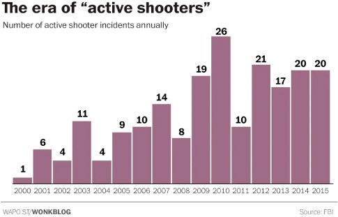

From Data Feminism: Washington Post Figure

## Interactivity with ggplotly

`plotly` is a high-level interface to plotly.js, based on [d3.js](https://d3js.org/) which provides an easier-to-use interface for interactive graphics.

There are two main approaches to initialize a plotly object:

- transforming a `ggplot2` object with `ggplotly()` – this converts a `ggplot()` object into an interactive `plot_ly()` object, but it won’t work for every figure.
- setting up aesthetics mappings with `plot_ly()` directly – this is a different plotting system, so harder to learn, but more customizable.

To the Script!

`plotly` will automatically include the ability to

- hover over a point to see the included values
- zoom in by selecting (click+drag) a region of the plot
- subset to specific groups by clicking their names in the legend
- download as a png file

See the [Sievert book](https://plotly-r.com/overview.html) for more!

## Putting Stuff online

- [RPubs](https://rpubs.com/) allows free hosting of static single-file R Markdown content – just click the “Publish” button on your html file!
- [GitHub Pages](https://pages.github.com/), if you’re a GitHub user, allows hosting of Markdown and HTML files from the GitHub repository (that’s how [my other class page](https://commpaslab.github.io/lpps5360/) is hosted)
- A web server like [Netlify](https://www.netlify.com/) (Here’s [a great webinar](https://www.rstudio.com/resources/webinars/sharing-on-short-notice-how-to-get-your-materials-online-with-r-markdown/) on sharing R markdown files, and other sources, on Netlify)

See the chapter in [Xie’s R Markdown book](https://bookdown.org/yihui/rmarkdown-cookbook/html-share.html) for more!

## Tables!

Sometimes you just want a table, especially in an interactive report (R Markdown style). Tables are great for

- Looking up or compare individual observations/values
- Including detail and summary values
- Displaying precise values

Options for creating better tables:

- [knitr::kable + kableExtra](https://cran.r-project.org/web/packages/kableExtra/vignettes/awesome_table_in_html.html): The `kable()` function, “a very simple table generator,” is defined by the `knitr` package. Probably the easiest “pretty” table in R Markdown.
- [DT::datatable](https://rstudio.github.io/DT/): The `datatable()` function provides an R interface to the JavaScript library DataTables to produce interactive tables; automatically searchable, sortable.

To the Script!

See the [Keye’s post](https://rfortherestofus.com/2019/11/how-to-make-beautiful-tables-in-r/) for more on `gt`, `reactable` and others!

## XKCD Inspiration

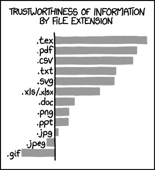

XKCD, Randall Munroe, https://xkcd.com/1301/